# Corona Virus Testing (US)

## Status of data

```
These graphs were last updated on Friday Apr 24, 2020, 12:38 PM
```

## Source of data

The following summarizes COVID-19 statistics obtained from the covidtracking.com API: https://covidtracking.com/api/.

## Visualizations

### Tests performed

**Figure 1**. To assess the increasing COVID-19 testing in the US, the number of **new** tests reported each day are summarized below.

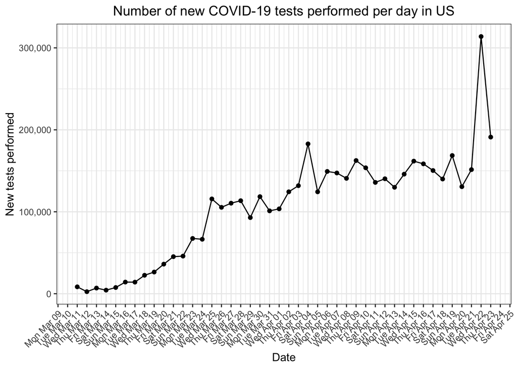

**Figure 2**. The cumulative number of tests performed to date.

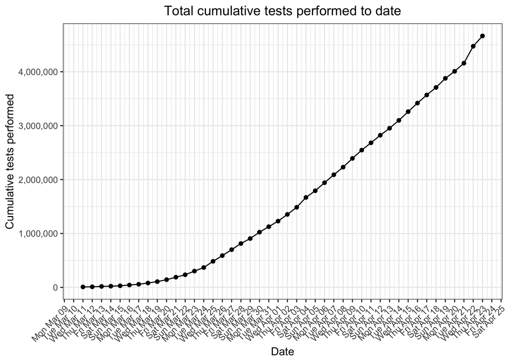

**Figure 3**. Change in test capacity from previous day

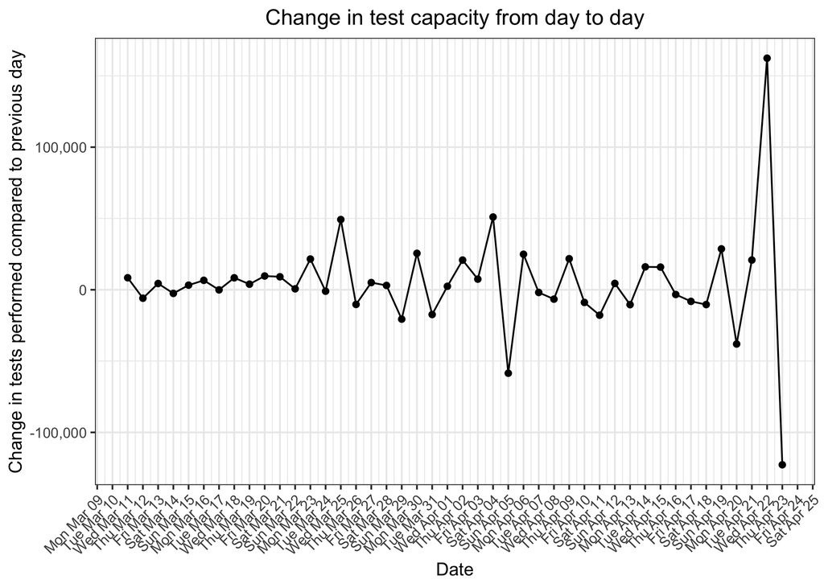

### Positive cases

**Figure 4**. The number of **new** positive cases reported each day are summarized below.

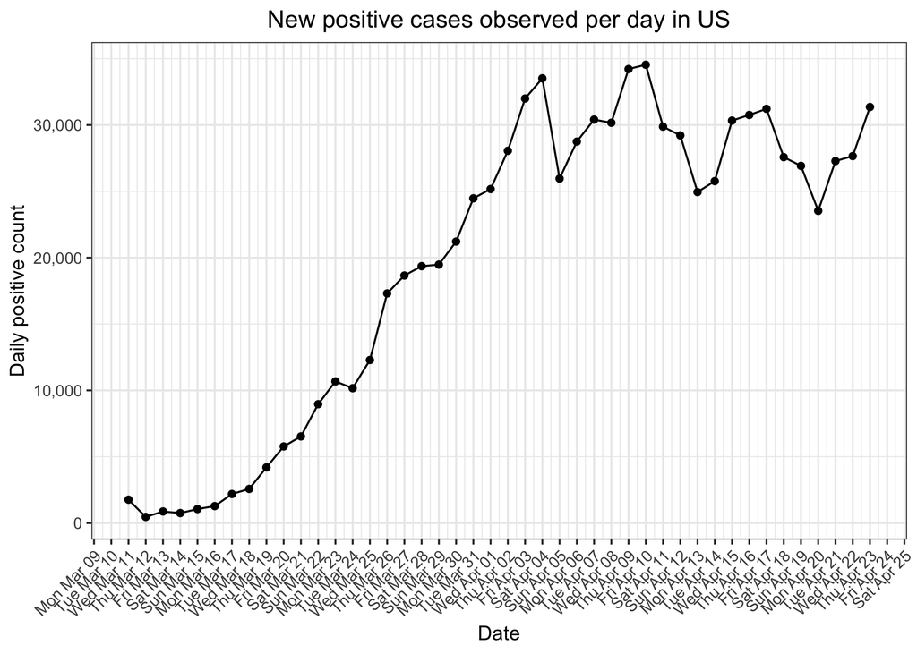

**Figure 5**. The cumulative number total positive cases reported to date.

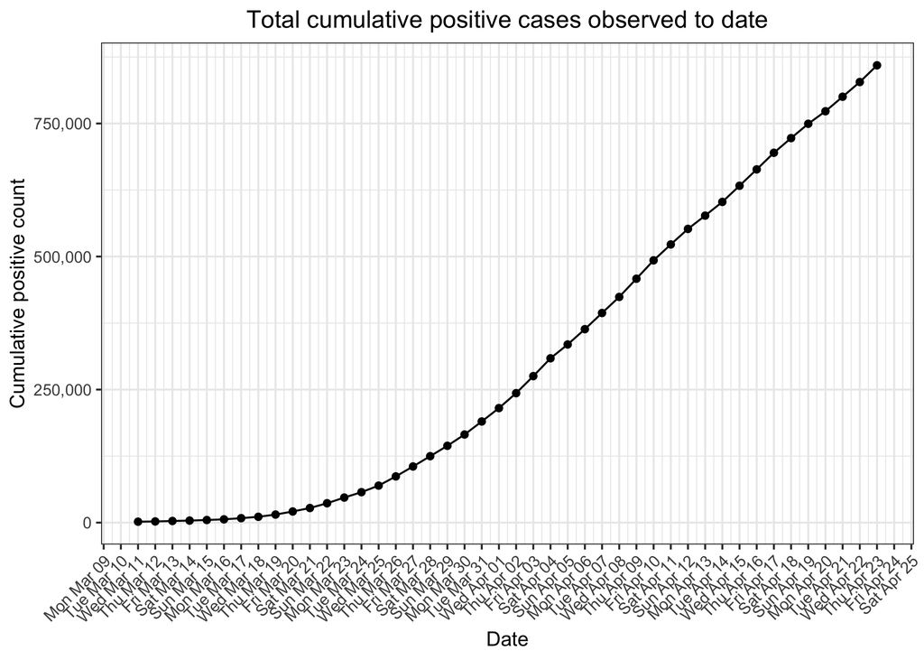

### Positive test rate

**Figure 6**. This graph shows the rate of positive tests observed out of all the tests performed on that same day. As the testing capacity increases we might start to see more people getting test who have less obvious symtoms, more people being tested out of caution, or to assure safety for working with the public, etc. If that is the case we might see the positive test rate start to drop as testing become widely available. On the other hand, if infection in the community is already widespread we might not see as much of a drop here.

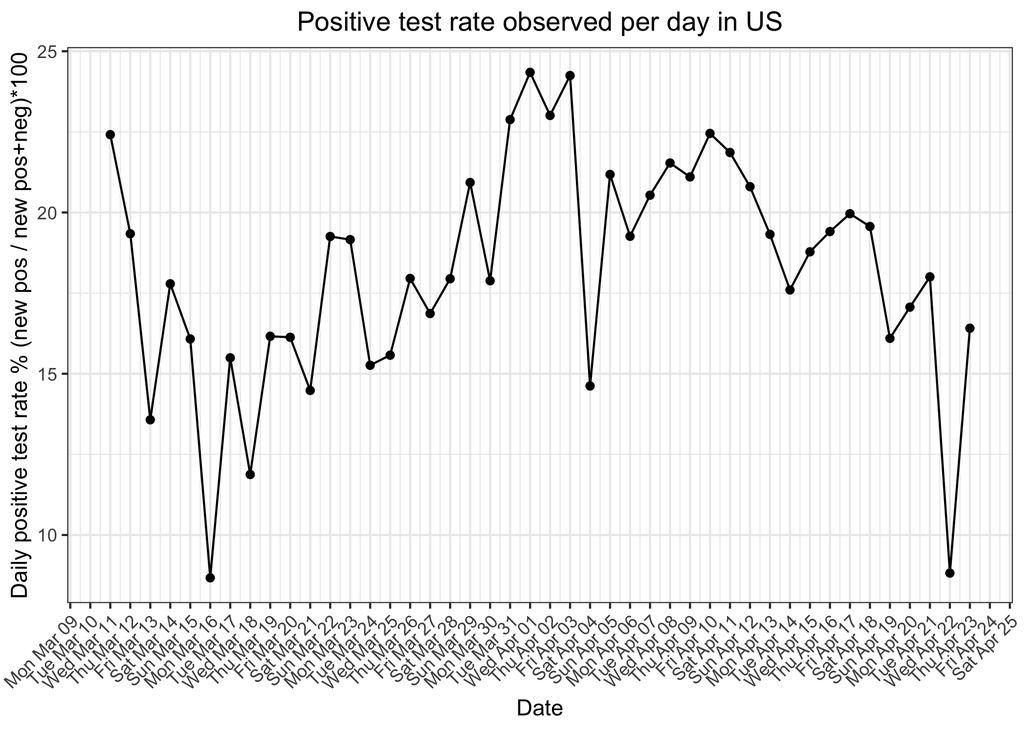

**Figure 7**. This graph is similar to the previous one but shows the cumulative positive test rate. We should see a similar trend here that as the pandemic passes and testing becomes widely available, the number of negative results will accumulate while the number of positive results slows. Over time, if the outbreak is contained this number should drop. On the other hand, if the outbreak continues to spread, many positives will continue to accumulate. If the rate of community infection is already high or continues to grow, this rate could actually still increase in the coming weeks.

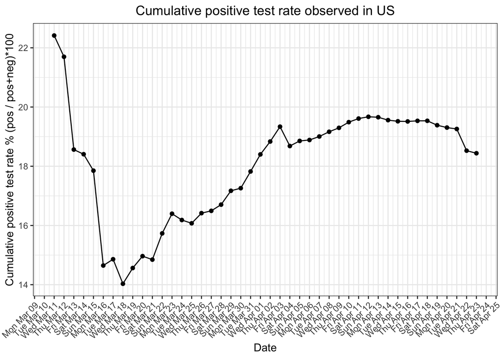

### Deaths

**Figure 8**. Number of new deaths observed each day. Pretty self explanatory. We want this to trend downwards…

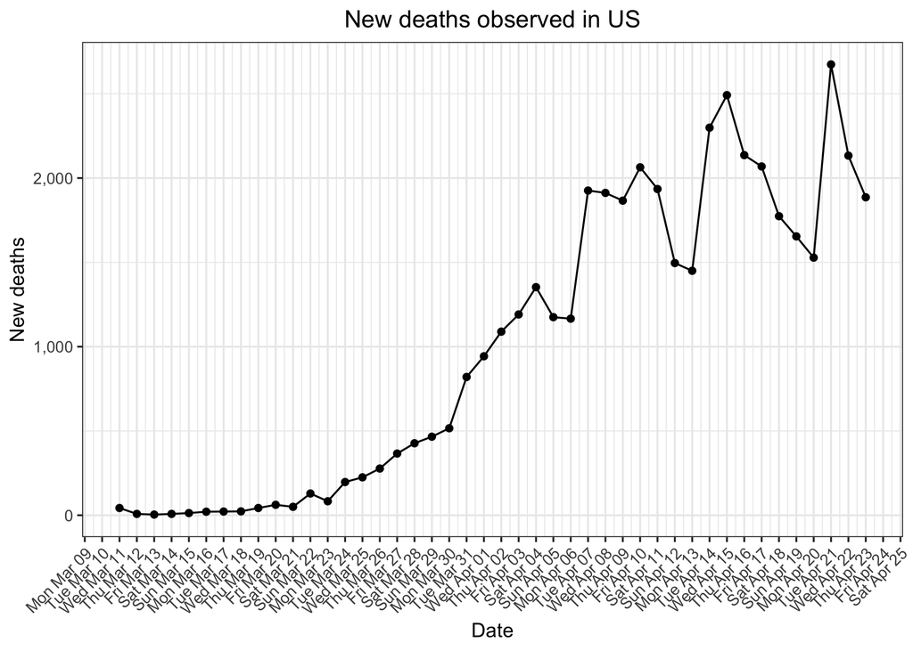

**Figure 9**. Cumulative deaths observed to date.

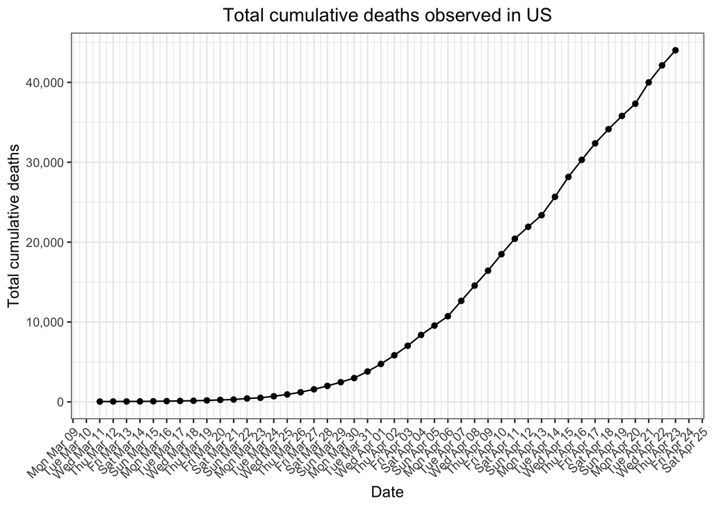

### Death rate

**Figure 10**. The overall cumulative apparent death rate. An overall estimate of the deadliness of the disease. As testing becomes more widespread and larger numbers of people are tested (even those with less severe symptoms) this number will hopefully drop. In the early days of the outbreak, many of those tested were presumably those with the worst symptoms. This contributes to a very high apparent fatality rate. As testing becomes more widespread, this rate should drop. However, unless testing becomes very widespread and systematic, it will probably always overestimate the true lethality of the disease because some will get the virus, remain healthy and never get tested.

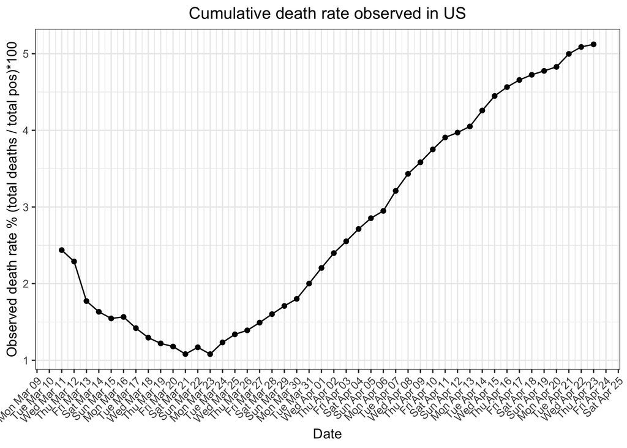

## Executive summary

The following pulls some reference values from the data based on the latest update a summarizes a few key numbers:

[output not shown]